# Ground-Motion Model Regression with Spatial Correlations using INLA

Nicolas Kuehn[^1]

04 April, 2023

# 1 Introduction

This documet contains code to estimtate empirical ground-motion models (GMMs), while taking spatial correlations (of within-event/within-site residuals) into account. The models are estimated with the R-INLA package (https://www.r-inla.org/) (Rue et al. 2017). Such regressions are similar to the ones proposed by Jayaram and Baker (2010) and Ming et al. (2019), but in a Bayesian context.

We fit a model of the form
$$Y = f(\vec{c},\vec{x}) + \delta B + \delta S + \delta C(\vec{t}_s) +
\delta W_0$$
where $\delta B$ and $\delta S$ are the typical event and site terms, and $\delta C(\vec{t}_s)$ is a spatially correlated within-event/within-site residual term, dependent on the spatial coordinate $\vec{t}_s$ of the stations. $f(\vec{c},\vec{x})$ is the base functional form, wth coefficients $\vec{c}$ and predictors $\vec{x}$. The data is the Italian dat of the ITA18 model (Lanzano et al. 2019), used also in Caramenti et al. (2022). The underlying functional form is the same as for the ITA18 model.

Regressions are carried out using INLA Rue, Martino, and Chopin (2009) and the SPDE approximation Lindgren, Rue, and Lindström (2011). The spatial correlation model is a Mat`ern covariance function with $\nu = 1$.
$$\begin{aligned}
\delta C &\sim GP(0, \phi_c^2 k(\vec{t}, \vec{t}')) \\
k(\vec{t}, \vec{t}')) &= k(\vec{t}, \vec{t}') = \frac{2^{(1
- \nu)}}{\Gamma(\nu)} (\kappa |\vec{t} - \vec{t}'|)^\nu K_\nu
(\kappa |\vec{t} - \vec{t}'|)
\end{aligned}$$
The spatial range is defined as $\ell = \sqrt{8 \nu}/\kappa$.

# 2 Getting Started

First, we load the packages required for the analysis.

```r
# load required packages
library(ggplot2)
library(INLA)
library(inlabru)
library(tidyverse)
library(cowplot)
```

```r
lw <- 1.5
sp <- 4
wid <- 8
asp <- 0.8

theme_set(theme_bw() + theme(#panel.grid.minor = element_blank(),
  axis.title = element_text(size = 30),
  axis.text = element_text(size = 20),
  plot.title = element_text(size = 30),
  legend.text = element_text(size = 20),
  legend.title = element_text(size = 20),
  legend.key.width = unit(1, "cm"),
  legend.box.background = element_rect(colour = "black"),
  panel.grid = element_line(color = "gray",linewidth = 0.75)
))

breaks <- 10^(-10:10)
minor_breaks <- rep(1:9, 21)*(10^rep(-10:10, each=9))

cols <- c("darkblue", "dodgerblue1", "cadetblue2", "white")
cols2 <- rev(cols)
```

Define the Mat'ern correlation function.

```r
# Matern correlation
cMatern <- function(h, nu, kappa) {
  ifelse(h > 0, besselK(h * kappa, nu) * (h * kappa)^nu /
           (gamma(nu) * 2^(nu - 1)), 1)
}
```

# 3 Data

Load data, and define linear predictors and data frame for regression.

```r
### INLA
data <- read.csv(file.path('DATA', 'italian_data_pga_id_utm_stat.csv'))
data_dm <- rstan::read_rdump(file.path('DATA','dm_25x25.Rdata'))
data$R_epi <- sqrt(rowSums((data[,c('X_ev','Y_ev')] - data[,c('X_stat','Y_stat')])^2))

# Set linear predictors
mh = 5.5
mref = 5.324
h = 6.924
attach(data)
b1 = (mag-mh)*(mag<=mh)
b2 = (mag-mh)*(mag>mh)
c1 = (mag-mref)*log10(sqrt(JB_complete^2+h^2))
c2 = log10(sqrt(JB_complete^2+h^2))
c3 = sqrt(JB_complete^2+h^2)
f1 = as.numeric(fm_type_code == "SS")
f2 = as.numeric(fm_type_code == "TF")
k = log10(vs30/800)*(vs30<=1500)+log10(1500/800)*(vs30>1500)
y = log10(rotD50_pga)
detach(data)

n_rec <- length(b1)
eq <- data$EQID
stat <- data$STATID
n_eq <- max(eq)
n_stat <- max(stat)
n_cell <- data_dm$NCELL

data_reg <- data.frame(Y = y,
                       intercept = 1,
                       M1 = b1,
                       M2 = b2,
                       MlogR = c1,
                       logR = c2,
                       R = c3,
                       Fss = f1,
                       Frv = f2,
                       lnVS = k,
                       eq = eq,
                       stat = stat
)

# divide cell-specific distances by 100, to avoid small values of cell-specific
# coefficients and standard deviation
dm_sparse <- as(data_dm$RC/100,"dgCMatrix")
data_reg$idx_cell <- 1:nrow(data_reg)
```

# 4 Model Estimation

Set priors for hyperparameters. Defne both a Gamma prior fo the precision, as well as a penalized complexity prior.

```r
prior_prec_tau_lg    <- list(prec = list(prior = "loggamma", param = c(1.74, 0.0153)))
prior_prec_phiS2S_lg <- list(prec = list(prior = "loggamma", param = c(1.74, 0.0153)))
prior_prec_phiSS_lg  <- list(prec = list(prior = "loggamma", param = c(1.74, 0.0153)))

prior_prec_tau  <- list(prec = list(prior = 'pc.prec', param = c(0.4, 0.01)))
prior_prec_phiS2S  <- list(prec = list(prior = 'pc.prec', param = c(0.4, 0.01)))
prior_prec_phi0  <- list(prec = list(prior = 'pc.prec', param = c(0.4, 0.01)))
prior_prec_cell <- list(prec = list(prior = 'pc.prec', param = c(1, 0.01)))
```

## 4.1 Base Model without Spatial Correlation

First, fit base models without spatial correlations (one with event and site terms, one with only event terms).

```r
form <- Y ~ M1 + M2 + logR + MlogR + R + Fss + Frv + lnVS +
  f(eq, model = "iid", hyper = prior_prec_tau_lg) +
  f(stat, model = "iid",hyper = prior_prec_phiS2S_lg)

fit_inla <- inla(form,
                 data = data_reg,
                 family="gaussian",
                 control.family = list(hyper = prior_prec_phi0),
                 control.compute = list(dic = TRUE, cpo = TRUE, waic = TRUE)
)

form_eq <- Y ~ M1 + M2 + logR + MlogR + R + Fss + Frv + lnVS +
  f(eq, model = "iid", hyper = prior_prec_tau)

fit_inla_eq <- inla(form_eq,
                    data = data_reg,
                    family="gaussian",
                    control.family = list(hyper = prior_prec_phi0),
                    control.compute = list(dic = TRUE, cpo = TRUE, waic = TRUE)
)

# add residals to data frame
data_reg$deltaW <- data_reg$Y - fit_inla_eq$summary.fitted.values$mean
data_reg$deltaWS <- data_reg$Y - fit_inla$summary.fitted.values$mean
data_reg$deltaW2 <- data_reg$Y -
  (fit_inla$summary.fitted.values$mean - fit_inla$summary.random$stat$mean[data_reg$stat])
```

## 4.2 Regression with Spatially Correlated within-event/within-site Residuals

Next, estimate the model with spatial correlations. First, we define the mesh, and plot the mesh togethe with the data, color-coded by event.

```r
### make mesh
co_eq <- data[,c("X_ev","Y_ev")]
co_stat <- data[,c("X_stat","Y_stat")]

# define relative coordinates
co_stat2 <- co_stat - co_eq
data_reg$X_stat <- co_stat2[,1]
data_reg$Y_stat <- co_stat2[,2]

max.edge2    <- 5 #0.04
bound.outer2 <- 20 #0.3
mesh = inla.mesh.2d(loc=as.matrix(co_stat2),
                    max.edge = c(1,5)*max.edge2,
                    # - use 5 times max.edge in the outer extension/offset/boundary
                    cutoff = max.edge2,
                    offset = c(5 * max.edge2, bound.outer2))
print(mesh$n) # number of mesh nodes
```

```
## [1] 4929
```

```r
print(length(mesh$graph$tv[,1])) # number of triangles
```

```
## [1] 9728
```

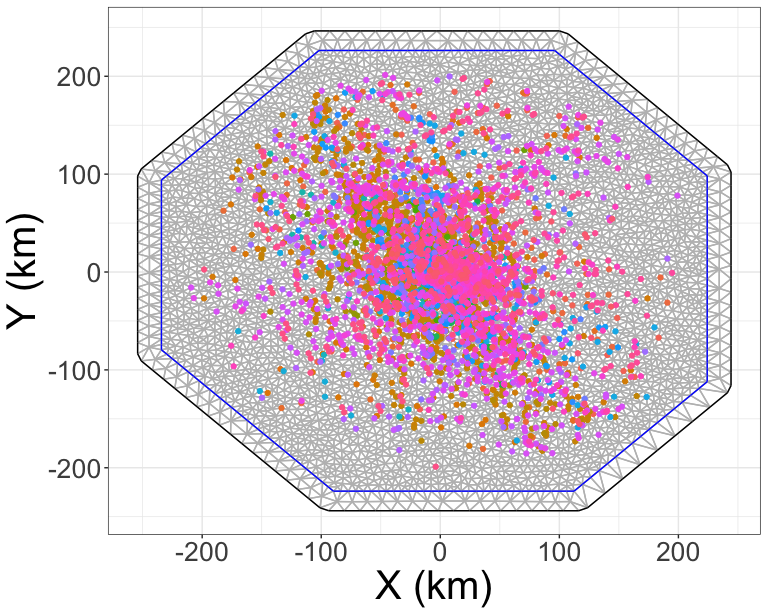

```r
ggplot() + theme_bw() + gg(mesh) +
  geom_point(data = data.frame(co_stat2), aes(x=X_stat,y=Y_stat, color = as.factor(eq))) +
  labs(x="X (km)", y="Y (km)") +
  theme(axis.title = element_text(size=30), axis.text.y = element_text(size=20),
        axis.text.x = element_text(size=20),
        legend.position = 'none')
```

Now we define the SPDE model, the prjection matrix (using the group feature for the records from dfferent events), and fit the model.

```r
# spde prior and define model
spde_rec <- inla.spde2.pcmatern(
  # Mesh and smoothness parameter
  mesh = mesh, alpha = 2,
  # P(practic.range < 0.3) = 0.5
  prior.range = c(50, 0.5),
  # P(sigma > 1) = 0.01
  prior.sigma = c(.4, 0.01))

# group model with stations
A_rec_gr     <- inla.spde.make.A(mesh, loc = as.matrix(co_stat2),
                                 group = eq, n.group = n_eq)
idx_rec_gr   <- inla.spde.make.index("idx_rec_gr",spde_rec$n.spde,
                                     n.group = n_eq)

# build stack
stk_spatial_rec <- inla.stack(
  data = list(y = data_reg$Y),
  A = list(A_rec_gr, 1),
  effects = list(idx_rec_gr = idx_rec_gr,
                 data_reg))

form_rec <- y ~ 0 + intercept + M1 + M2 + logR + MlogR + R + Fss + Frv + lnVS +
  f(eq, model = "iid", hyper = prior_prec_tau_lg) +
  f(stat, model = "iid",hyper = prior_prec_phiS2S_lg) +
  f(idx_rec_gr, model = spde_rec, group = idx_rec_gr.group,
                                  control.group = list(model = "iid"))

fit_inla_cor <- inla(form_rec,
                     data = inla.stack.data(stk_spatial_rec),
                     family="gaussian",
                     control.family = list(hyper = prior_prec_phi0),
                     control.predictor = list(A = inla.stack.A(stk_spatial_rec)),
                     control.compute = list(waic = TRUE),
                     control.inla = list(int.strategy = 'eb')
)
print(summary(fit_inla_cor))
```

```
##
## Call:
##    c("inla.core(formula = formula, family = family, contrasts = contrasts,
##    ", " data = data, quantiles = quantiles, E = E, offset = offset, ", "
##    scale = scale, weights = weights, Ntrials = Ntrials, strata = strata,
##    ", " lp.scale = lp.scale, link.covariates = link.covariates, verbose =
##    verbose, ", " lincomb = lincomb, selection = selection, control.compute
##    = control.compute, ", " control.predictor = control.predictor,
##    control.family = control.family, ", " control.inla = control.inla,
##    control.fixed = control.fixed, ", " control.mode = control.mode,
##    control.expert = control.expert, ", " control.hazard = control.hazard,
##    control.lincomb = control.lincomb, ", " control.update =
##    control.update, control.lp.scale = control.lp.scale, ", "
##    control.pardiso = control.pardiso, only.hyperparam = only.hyperparam,
##    ", " inla.call = inla.call, inla.arg = inla.arg, num.threads =
##    num.threads, ", " blas.num.threads = blas.num.threads, keep = keep,
##    working.directory = working.directory, ", " silent = silent, inla.mode
##    = inla.mode, safe = FALSE, debug = debug, ", " .parent.frame =
##    .parent.frame)")
## Time used:
##     Pre = 10.9, Running = 2870, Post = 21.6, Total = 2903
## Fixed effects:
##             mean    sd 0.025quant 0.5quant 0.975quant   mode kld
## intercept  3.410 0.066      3.280    3.410      3.540  3.410   0
## M1         0.249 0.066      0.119    0.249      0.378  0.249   0
## M2         0.072 0.094     -0.113    0.072      0.256  0.072   0
## logR      -1.428 0.038     -1.502   -1.428     -1.355 -1.428   0
## MlogR      0.264 0.030      0.206    0.264      0.322  0.264   0
## R         -0.003 0.000     -0.003   -0.003     -0.002 -0.003   0
## Fss        0.152 0.041      0.071    0.152      0.233  0.152   0
## Frv        0.063 0.038     -0.011    0.063      0.137  0.063   0
## lnVS      -0.458 0.040     -0.537   -0.458     -0.378 -0.458   0
##
## Random effects:
##   Name     Model
##     eq IID model
##    stat IID model
##    idx_rec_gr SPDE2 model
##
## Model hyperparameters:
##                                           mean     sd 0.025quant 0.5quant
## Precision for the Gaussian observations  73.67  2.908     68.101    73.62
## Precision for eq                         92.01 30.644     48.998    86.31
## Precision for stat                       25.02  1.559     22.087    24.97
## Range for idx_rec_gr                    131.38  9.608    113.668   130.95
## Stdev for idx_rec_gr                      0.22  0.008      0.204     0.22
##                                         0.975quant    mode
## Precision for the Gaussian observations     79.557  73.525
## Precision for eq                           167.832  75.696
## Precision for stat                          28.228  24.880
## Range for idx_rec_gr                       151.502 129.968
## Stdev for idx_rec_gr                         0.237   0.219
##
## Watanabe-Akaike information criterion (WAIC) ...: -4872.50
## Effective number of parameters .................: 1635.80
##
## Marginal log-Likelihood:  786.38
##  is computed
## Posterior summaries for the linear predictor and the fitted values are computed
## (Posterior marginals needs also 'control.compute=list(return.marginals.predictor=TRUE)')
```

## 4.3 Cell-Specific Attenuation

Now also include cell-specific attenuation.

```r
form_rec_cell <- y ~ 0 + intercept + M1 + M2 + logR + MlogR + R + Fss + Frv + lnVS +
  f(eq, model = "iid", hyper = prior_prec_tau_lg) +
  f(stat, model = "iid",hyper = prior_prec_phiS2S_lg) +
  f(idx_rec_gr, model = spde_rec, group = idx_rec_gr.group,
    control.group = list(model = "iid")) +
  f(idx_cell, model = "z", Z = dm_sparse, hyper = prior_prec_cell)

fit_inla_cell_cor <- inla(form_rec_cell,
                     data = inla.stack.data(stk_spatial_rec),
                     family="gaussian",
                     control.family = list(hyper = prior_prec_phi0),
                     control.predictor = list(A = inla.stack.A(stk_spatial_rec)),
                     control.compute = list(waic = TRUE),
                     control.inla = list(int.strategy = 'eb')
)
form_cell <- y ~ 0 + intercept + M1 + M2 + logR + MlogR + R + Fss + Frv + lnVS +
  f(eq, model = "iid", hyper = prior_prec_tau_lg) +
  f(stat, model = "iid",hyper = prior_prec_phiS2S_lg) +
  f(idx_cell, model = "z", Z = dm_sparse, hyper = prior_prec_cell)

fit_inla_cell <- inla(form_cell,
                      data = data_reg,
                      family="gaussian",
                      control.family = list(hyper = prior_prec_phi0),
                      control.compute = list(waic = TRUE)
)
```

## 4.4 Non-Stationary Model

Now a non-stationary model, based on ideas from Kuehn and Abrahamson (2020) and Liu, Macedo, and Kuehn (2022). Here, the spatial range $\ell$ is dependent on distance to the source
$$\ell = \exp \left[ a + b \frac{\min(R_{EPI}, 80)}{80}\right]$$
For implementation details, see Chapter 5 of Krainski et al. (2019) (https://becarioprecario.bitbucket.io/spde-gitbook/index.html).

```r
# set mesh distances
ref_d <- 80
D_b_mesh <- sqrt(mesh$loc[,1]^2 + mesh$loc[,2]^2)
D_b_mesh[D_b_mesh > ref_d] <- ref_d
D_b_mesh <- D_b_mesh/ref_d

# correlation depends on distance to basin
nu <- 1
alpha <- nu + 2 / 2
# log(kappa)
logkappa0 <- log(8 * nu) / 2
# log(tau); in two lines to keep code width within range
logtau0 <- (lgamma(nu) - lgamma(alpha) -1 * log(4 * pi)) / 2
logtau0 <- logtau0 - logkappa0

# SPDE model
spde_rec_ns <- inla.spde2.matern(mesh,
                                 B.tau = cbind(logtau0, -1, nu, nu * D_b_mesh),
                                 B.kappa = cbind(logkappa0, 0, -1, -1 * D_b_mesh),
                                 theta.prior.mean = rep(0, 3),
                                 #theta.prior.mean = c(-0.7, 2.3, 0.5),
                                 theta.prior.prec = rep(1, 3))

# build stack
stk_spatial_rec <- inla.stack(
  data = list(y = data_reg$Y),
  A = list(A_rec_gr, 1),
  effects = list(idx_rec_gr = idx_rec_gr,
                 data_reg))

form_rec_ns <- y ~ 0 + intercept + M1 + M2 + logR + MlogR + R + Fss + Frv + lnVS +
  f(eq, model = "iid", hyper = prior_prec_tau_lg) +
  f(stat, model = "iid",hyper = prior_prec_phiS2S_lg) +
  f(idx_rec_gr, model = spde_rec_ns, group = idx_rec_gr.group,
    control.group = list(model = "iid"))

fit_inla_cor_ns <- inla(form_rec_ns,
                        data = inla.stack.data(stk_spatial_rec),
                        family="gaussian",
                        control.family = list(hyper = prior_prec_phi0),
                        control.predictor = list(A = inla.stack.A(stk_spatial_rec)),
                        control.compute = list(waic = TRUE)
)
print(summary(fit_inla_cor_ns))
```

```
##
## Call:
##    c("inla.core(formula = formula, family = family, contrasts = contrasts,
##    ", " data = data, quantiles = quantiles, E = E, offset = offset, ", "
##    scale = scale, weights = weights, Ntrials = Ntrials, strata = strata,
##    ", " lp.scale = lp.scale, link.covariates = link.covariates, verbose =
##    verbose, ", " lincomb = lincomb, selection = selection, control.compute
##    = control.compute, ", " control.predictor = control.predictor,
##    control.family = control.family, ", " control.inla = control.inla,
##    control.fixed = control.fixed, ", " control.mode = control.mode,
##    control.expert = control.expert, ", " control.hazard = control.hazard,
##    control.lincomb = control.lincomb, ", " control.update =
##    control.update, control.lp.scale = control.lp.scale, ", "
##    control.pardiso = control.pardiso, only.hyperparam = only.hyperparam,
##    ", " inla.call = inla.call, inla.arg = inla.arg, num.threads =
##    num.threads, ", " blas.num.threads = blas.num.threads, keep = keep,
##    working.directory = working.directory, ", " silent = silent, inla.mode
##    = inla.mode, safe = FALSE, debug = debug, ", " .parent.frame =
##    .parent.frame)")
## Time used:
##     Pre = 9.52, Running = 48942, Post = 73.2, Total = 49025
## Fixed effects:
##             mean    sd 0.025quant 0.5quant 0.975quant   mode kld
## intercept  3.427 0.077      3.275    3.427      3.577  3.427   0
## M1         0.266 0.071      0.126    0.266      0.404  0.266   0
## M2         0.096 0.096     -0.093    0.096      0.285  0.096   0
## logR      -1.446 0.046     -1.536   -1.446     -1.356 -1.446   0
## MlogR      0.245 0.034      0.180    0.245      0.311  0.245   0
## R         -0.003 0.000     -0.003   -0.003     -0.002 -0.003   0
## Fss        0.133 0.042      0.052    0.133      0.215  0.133   0
## Frv        0.071 0.039     -0.005    0.071      0.147  0.071   0
## lnVS      -0.463 0.040     -0.540   -0.463     -0.385 -0.463   0
##
## Random effects:
##   Name     Model
##     eq IID model
##    stat IID model
##    idx_rec_gr SPDE2 model
##
## Model hyperparameters:
##                                           mean     sd 0.025quant 0.5quant
## Precision for the Gaussian observations  92.48  3.779      85.15    92.45
## Precision for eq                        109.43 38.544      56.92   101.79
## Precision for stat                       25.74  1.564      22.80    25.68
## Theta1 for idx_rec_gr                    -1.56  0.027      -1.61    -1.56
## Theta2 for idx_rec_gr                     3.22  0.092       3.05     3.22
## Theta3 for idx_rec_gr                     2.17  0.112       1.94     2.17
##                                         0.975quant  mode
## Precision for the Gaussian observations     100.03 92.45
## Precision for eq                            205.87 87.90
## Precision for stat                           28.96 25.58
## Theta1 for idx_rec_gr                        -1.50 -1.56
## Theta2 for idx_rec_gr                         3.41  3.21
## Theta3 for idx_rec_gr                         2.38  2.18
##
## Watanabe-Akaike information criterion (WAIC) ...: -5729.54
## Effective number of parameters .................: 1779.54
##
## Marginal log-Likelihood:  951.38
##  is computed
## Posterior summaries for the linear predictor and the fitted values are computed
## (Posterior marginals needs also 'control.compute=list(return.marginals.predictor=TRUE)')
```

# 5 Model Comparison

## 5.1 WAIC

First, we compare the models by the widely applicable information criterion (WAIC) Vehtari, Gelman, and Gabry (2017). A lower value means better predictive capability. The base models do not include spatial correlations.

```r
data.frame(model =c("Base","Base only dB","Base cell","Stationary","Cell","Non-Stationary"),
           waic = c(fit_inla$waic$waic, fit_inla_eq$waic$waic, fit_inla_cell$waic$waic,
                    fit_inla_cor$waic$waic, fit_inla_cell_cor$waic$waic, fit_inla_cor_ns$waic$waic)) %>%
  knitr::kable(digits = 2, row.names = FALSE,
             caption = "Information Criteria (WAIC) for different INLA models
             estimated on the Italian data.")
```

Information Criteria (WAIC) for different INLA models estimated on the Italian data.

| model | waic |
| --- | --- |
| Base | -780.83 |
| Base only dB | 2398.77 |
| Base cell | -1468.47 |
| Stationary | -4872.50 |
| Cell | -4913.97 |
| Non-Stationary | -5729.54 |

## 5.2 Posterior Plots

First, plot the posterior of the spatial range of the models which include spatial correlation. For the non-stationary model, we plot the value of the spatial range corresponding to $R_{EPI} = 0$km.

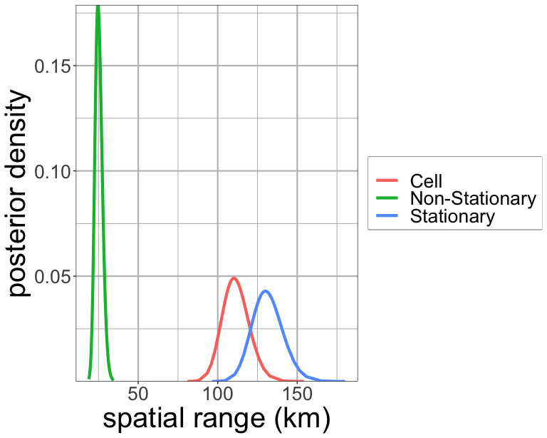

Posterior distribution of spatial range for different models.

```r
xlab <- 'spatial range (km)'
ylab <- 'posterior density'
rbind(data.frame(fit_inla_cor$marginals.hyperpar$`Range for idx_rec_gr`, mod = "Stationary"),
      data.frame(fit_inla_cell_cor$marginals.hyperpar$`Range for idx_rec_gr`, mod = "Cell"),
      data.frame(inla.tmarginal(function(x) exp(x),
                                      fit_inla_cor_ns$internal.marginals.hyperpar$`Theta2 for idx_rec_gr`),
                 mod = "Non-Stationary")) %>%
  ggplot() +
  geom_line(aes(x = x, y = y, color = mod), linewidth = lw) +
  labs(x = xlab, y = ylab) +
  guides(color = guide_legend(title=NULL)) +
  scale_y_continuous(expand = c(0, 0))
```

Now, plot the posterior distribution of the standard deviation $\phi_c$, which is associated with the spatial correlation structure.

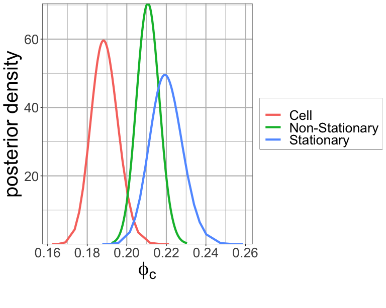

Posterior distribution of phi_c for different models.

```r
xlab <- expression(atop(paste(phi[c])))
ylab <- 'posterior density'
rbind(data.frame(fit_inla_cor$marginals.hyperpar$`Stdev for idx_rec_gr`, mod = "Stationary"),
      data.frame(fit_inla_cell_cor$marginals.hyperpar$`Stdev for idx_rec_gr`, mod = "Cell"),
      data.frame(inla.tmarginal(function(x) exp(x),
                                      fit_inla_cor_ns$internal.marginals.hyperpar$`Theta1 for idx_rec_gr`),
                 mod = "Non-Stationary")) %>%
  ggplot() +
  geom_line(aes(x = x, y = y, color = mod), linewidth = lw) +
  labs(x = xlab, y = ylab) +
  guides(color = guide_legend(title=NULL)) +
  scale_y_continuous(expand = c(0, 0))
```

# 6 Plot of Correlations

## 6.1 Correlation vs Distance

Here, we plot the values of the Mat'ern correlation function against separation distance, using the parameters from the stationary model. The uncertainty corresponds to the 95% uncertainty interval of the spatial range.

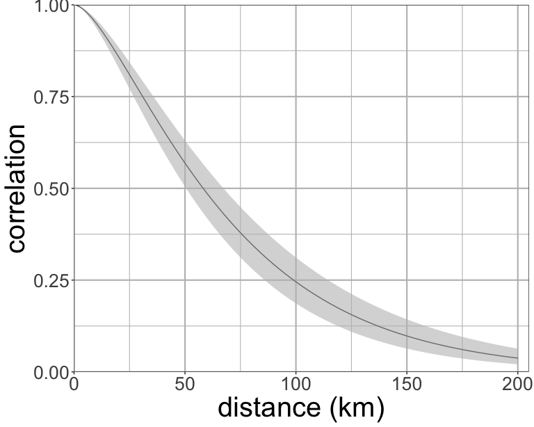

```r
nu <- 1
range <- as.numeric(fit_inla_cor$summary.hyperpar[4,c("0.025quant", "0.5quant", "0.975quant")])
kappa <- sqrt(8*nu)/range
xv <- 1:200

xlab <- 'distance (km)'
ylab <- 'correlation'
data.frame(x = xv, q025 = cMatern(xv, nu, kappa[1]), q05 = cMatern(xv, nu, kappa[2]),
                 q975 = cMatern(xv, nu, kappa[3])) %>%
  ggplot() +
  geom_line(aes(x = x, y = q05)) +
  geom_ribbon(aes(x = x, ymin = q025, ymax = q975), fill = 'gray', alpha = 0.6) +
  scale_y_continuous(expand = c(0, 0), limits = c(0,1.)) +
  scale_x_continuous(expand = c(0, 0), limits = c(0,205.)) +
  labs(x = xlab, y = ylab)
```

## 6.2 Spatial Range

Now we plot the value of he spatial range, dependent n source-to-site distance, for the non-stationary model.

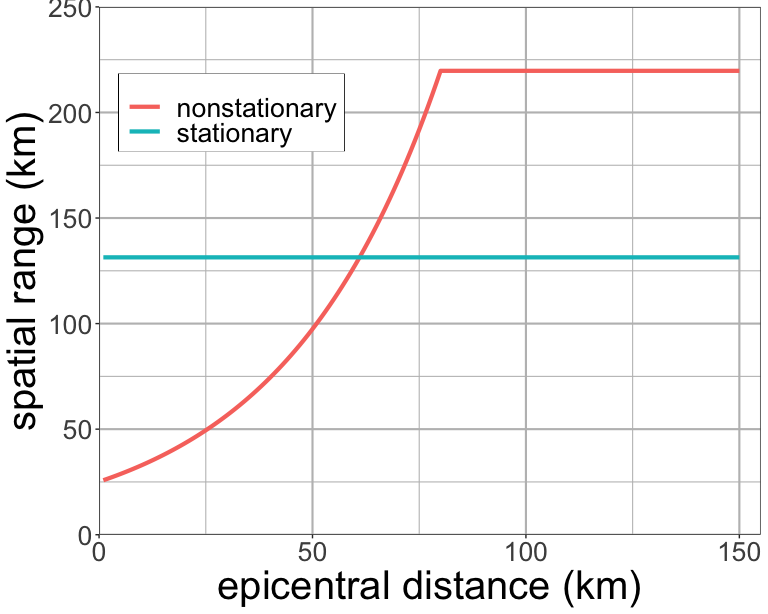

```r
xv <- 1:150
xv2 <- xv
xv2[xv > ref_d] <- ref_d
xv2 <- xv2 / ref_d
par_hyper <- fit_inla_cor_ns$summary.hyperpar$mean

xlab <- 'epicentral distance (km)'
ylab<- 'spatial range (km)'
data.frame(x = xv, nonstationary = exp(par_hyper[5] + par_hyper[6] * xv2),
                 stationary = fit_inla_cor$summary.hyperpar$mean[4]) %>%
  pivot_longer(!x) %>%
  ggplot() +
  geom_line(aes(x = x, y = value, color = name), linewidth = lw) +
  scale_y_continuous(limits = c(0,250), expand = c(0,0)) +
  scale_x_continuous(limits = c(0,155), expand = c(0,0)) +
  labs(x = xlab, y = ylab) +
  theme(legend.position = c(0.2,0.8)) +
  guides(color = guide_legend(title=NULL))
```

## 6.3 Correlation kernels

Now we plot the correlation kernel for the stationary and non-stationary correlation functions. The non-stationary correlation depends on the distance to the source, so is different for sies with different coordinates.

We use the median of the posterior distribution as the parameters of the spatial correlation structure. First, we calculate the precision matrix using `inla.spde2.precision`, which is then used to calculate the correlation values at the mesh nodes. The function `book.spatial.correlation` is from Krainski et al. (2019) (https://www.r-inla.org/learnmore/books).

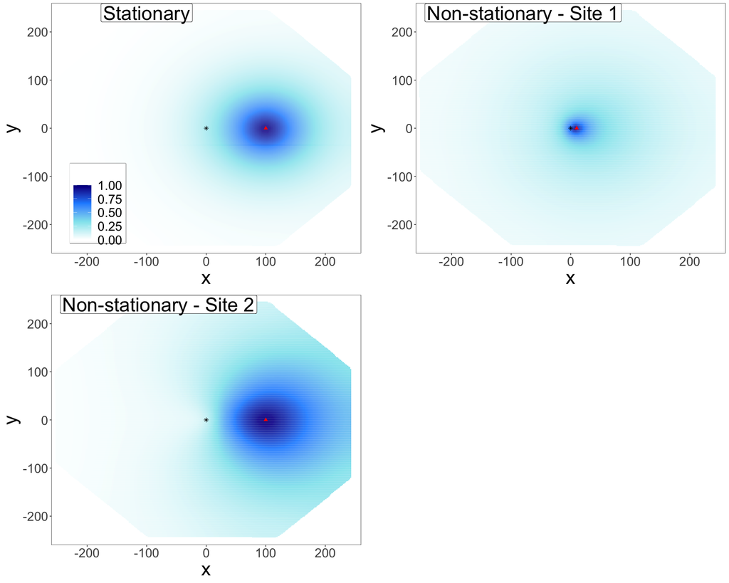

```r
theta_ns <- fit_inla_cor_ns$summary.hyperpar[c(4,5,6),"0.5quant"]
Q_ns <- inla.spde2.precision(spde_rec_ns, theta = theta_ns)

theta_stat <- fit_inla_cor$internal.summary.hyperpar[c(4,5),"0.5quant"]
Q_stat <- inla.spde2.precision(spde_rec, theta = theta_stat)

corr_ns1 <- book.spatial.correlation(Q_ns, c(10, 0), mesh)
corr_ns2 <- book.spatial.correlation(Q_ns, c(100, 0), mesh)
corr_stat <- book.spatial.correlation(Q_stat, c(100, 0), mesh)

df <- data.frame(label = "Non-stationary - Site 1", x = -80, y= 240)
pl_ns1 <- ggplot()+gg(mesh, color=corr_ns1, nx = 300, ny =300) +
  scale_fill_gradientn(colours = cols2, name = "", limits = c(0.,1)) +
  geom_point(data.frame(x = 0, y = 0), mapping = aes(x= x, y = y), shape = 8, size = 2) +
  geom_point(data.frame(x = 10, y = 0), mapping = aes(x= x, y = y), shape = 17, color = 'red', size = 2) +
  theme(panel.grid = element_blank(),
        legend.position = 'none') +
  scale_x_continuous(limits = c(-260,260),expand = c(0,0)) +
  scale_y_continuous(limits = c(-260,260),expand = c(0,0)) +
  geom_label(df, mapping = aes(x = x, y = y, label = label), size = 30/2.8)

df <- data.frame(label = "Non-stationary - Site 2", x = -80, y= 240)
pl_ns2 <- ggplot()+gg(mesh, color=corr_ns2, nx = 300, ny =300) +
  scale_fill_gradientn(colours = cols2, name = "", limits = c(0.,1)) +
  geom_point(data.frame(x = 0, y = 0), mapping = aes(x= x, y = y), shape = 8, size = 2) +
  geom_point(data.frame(x = 100, y = 0), mapping = aes(x= x, y = y), shape = 17, color = 'red', size = 2) +
  theme(panel.grid = element_blank(),
        legend.position = 'none') +
  scale_x_continuous(limits = c(-260,260),expand = c(0,0)) +
  scale_y_continuous(limits = c(-260,260),expand = c(0,0)) +
  geom_label(df, mapping = aes(x = x, y = y, label = label), size = 30/2.8)

df <- data.frame(label = "Stationary", x = -100, y= 240)
pl_stat <- ggplot()+gg(mesh, color=corr_stat, nx = 500, ny =500) +
  scale_fill_gradientn(colours = cols2, name = "", limits = c(0.,1)) +
  geom_point(data.frame(x = 0, y = 0), mapping = aes(x= x, y = y), shape = 8, size = 2) +
  geom_point(data.frame(x = 100, y = 0), mapping = aes(x= x, y = y), shape = 17, color = 'red', size = 2) +
  theme(panel.grid = element_blank(),
        legend.position = c(0.15,0.2)) +
  scale_x_continuous(limits = c(-260,260),expand = c(0,0)) +
  scale_y_continuous(limits = c(-260,260),expand = c(0,0)) +
  geom_label(df, mapping = aes(x = x, y = y, label = label), size = 30/2.8)

plot_grid(pl_stat, pl_ns1, pl_ns2, ncol = 2, nrow = 2)
```

# References

Caramenti, Luca, Alessandra Menafoglio, Sara Sgobba, and Giovanni Lanzano. 2022. “Multi-source geographically weighted regression for regionalized ground-motion models.” *Spatial Statistics* 47 (March): 100610. https://doi.org/10.1016/j.spasta.2022.100610.

Jayaram, Nirmal, and Jack W. Baker. 2010. “Considering Spatial Correlation in Mixed-Effects Regression and the Impact on Ground-Motion Models.” *Bulletin of the Seismological Society of America* 100 (6): 3295–3303. https://doi.org/10.1785/0120090366.

Krainski, Elias, Virgilio Gómez-Rubio, Haakon Bakka, Amanda Lenzi, Daniela Castro-Camilo, Daniel Simpson, Finn K. Lindgren, and Håvard Rue. 2019. *Advanced Spatial Modeling with Stochastic Partial Differential Equations Using R and INLA*. Boca-Raton, FL: Chapman; Hall/CRC.

Kuehn, Nicolas M., and Norman A. Abrahamson. 2020. “Spatial correlations of ground motion for non-ergodic seismic hazard analysis.” *Earthquake Engineering & Structural Dynamics* 49 (1): 4–23. https://doi.org/10.1002/eqe.3221.

Lanzano, Giovanni, Lucia Luzi, Francesca Pacor, Chiara Felicetta, Rodolfo Puglia, Sara Sgobba, and Maria D’Amico. 2019. “A Revised Ground‐Motion Prediction Model for Shallow Crustal Earthquakes in Italy.” *Bulletin of the Seismological Society of America* 109 (2): 525–40. https://doi.org/10.1785/0120180210.

Lindgren, Finn, Håvard Rue, and Johan Lindström. 2011. “An explicit link between gaussian fields and gaussian markov random fields: The stochastic partial differential equation approach.” *Journal of the Royal Statistical Society. Series B: Statistical Methodology* 73 (4): 423–98. https://doi.org/10.1111/j.1467-9868.2011.00777.x.

Liu, Chenying, Jorge Macedo, and Nicolas Kuehn. 2022. “Spatial correlation of systematic effects of non-ergodic ground motion models in the Ridgecrest area.” *Bulletin of Earthquake Engineering*, no. 0123456789 (July). https://doi.org/10.1007/s10518-022-01441-9.

Ming, Deyu, Chen Huang, Gareth W Peters, and Carmine Galasso. 2019. “An Advanced Estimation Algorithm for Ground‐Motion Models with Spatial Correlation.” *Bulletin of the Seismological Society of America* 109 (2): 541–66. https://doi.org/10.1785/0120180215.

Rue, Håvard, Sara Martino, and Nicolas Chopin. 2009. “Approximate Bayesian inference for latent Gaussian models by using integrated nested Laplace approximations.” *Journal of the Royal Statistical Society: Series B (Statistical Methodology)* 71 (2): 319–92. https://doi.org/10.1111/j.1467-9868.2008.00700.x.

Rue, Håvard, Andrea Riebler, Sigrunn H. Sørbye, Janine B. Illian, Daniel P. Simpson, and Finn K. Lindgren. 2017. “Bayesian Computing with INLA: A Review.” *Annual Review of Statistics and Its Application* 4 (1): 395–421. https://doi.org/10.1146/annurev-statistics-060116-054045.

Vehtari, Aki, Andrew Gelman, and Jonah Gabry. 2017. “Practical Bayesian model evaluation using leave-one-out cross-validation and WAIC.” *Statistics and Computing* 27 (5): 1413–32. https://doi.org/10.1007/s11222-016-9696-4.

Watanabe, Sumio. 2013. “A widely applicable bayesian information criterion.” *Journal of Machine Learning Research* 14 (1): 867–97. https://arxiv.org/abs/1208.6338.

[^1]: Unversity of California, Los Angeles, kuehn@ucla.edu